# task13

Edgaras Petrauskas

Wednesday, May 04, 2016

## 1. For the following series, find an appropriate Box-Cox transformation and order of differencing in order to obtain stationary data.

- 1. usnetelec
- 2. usgdp
- 3. mcopper
- 4. enplanements
- 5. visitors

```r
library(fpp)
```

- **(a) usnetelec**

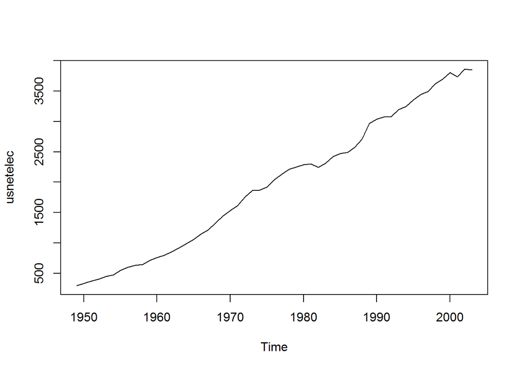

```r
plot(usnetelec) # duomenys nestacionarūs, nes matomas trendas
```

```r
lambdaa <- BoxCox.lambda(usnetelec) # lambdos radimas
lambdaa
```

```
## [1] 0.5167714
```

```r
a <- BoxCox(usnetelec, lambdaa) # įvykdoma Box-Cox transformacija
```

A useful R function is ndiffs() which uses these tests to determine the appropriate number of first differences required for a non-seasonal time series. (Iš: https://www.otexts.org/fpp/8/1)

```r
na <- ndiffs(usnetelec) # surandama diferencijavimo eilė
na
```

```
## [1] 1
```

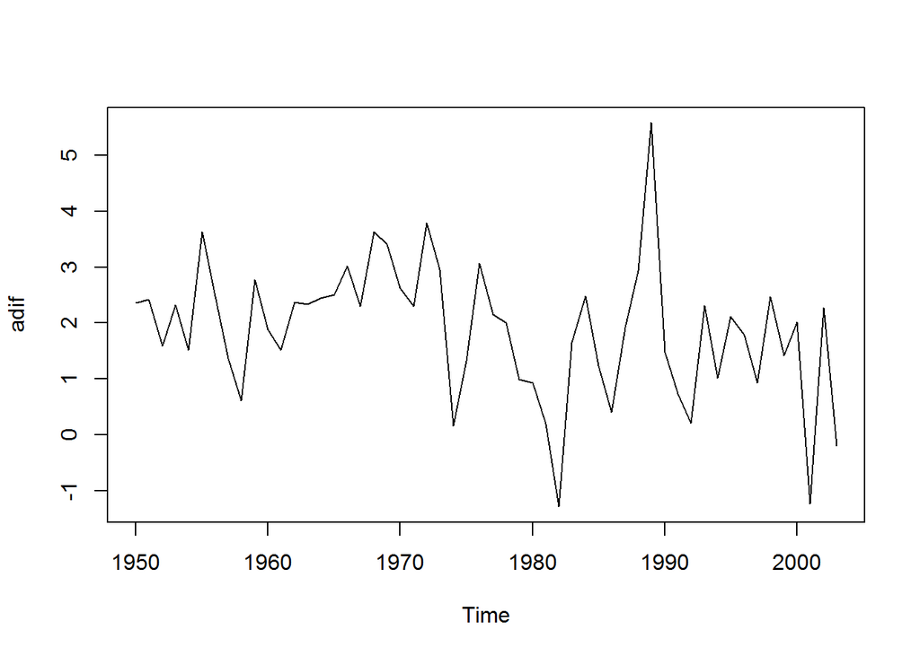

```r
adif <- diff(a, differences=na) # diferencijuojami duomenys
plot(adif)
```

KPSS testas leis nustatyti, ar H0: duomenys stacionarūs.

```r
kpss.test(adif)
```

```
##
##  KPSS Test for Level Stationarity
##
## data:  adif
## KPSS Level = 0.4851, Truncation lag parameter = 1, p-value =
## 0.04503
```

p-value = 0.045 < 0.05, vadinasi duomenys nėra stacionarūs. Galime bandyti diferencijuoti dar kartą ir tikėtis reikiamų savybių.

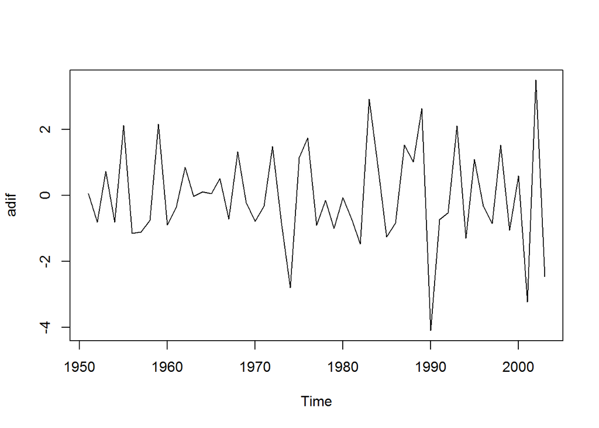

```r
adif <- diff(a, differences=2)
plot(adif)
```

```r
kpss.test(adif)
```

```
##
##  KPSS Test for Level Stationarity
##
## data:  adif
## KPSS Level = 0.0292, Truncation lag parameter = 1, p-value = 0.1
```

Šį kartą p-value = 0.1 > 0.05, vadinasi transformuoti duomenys yra stacionarūs.

- **(b) usgdp**

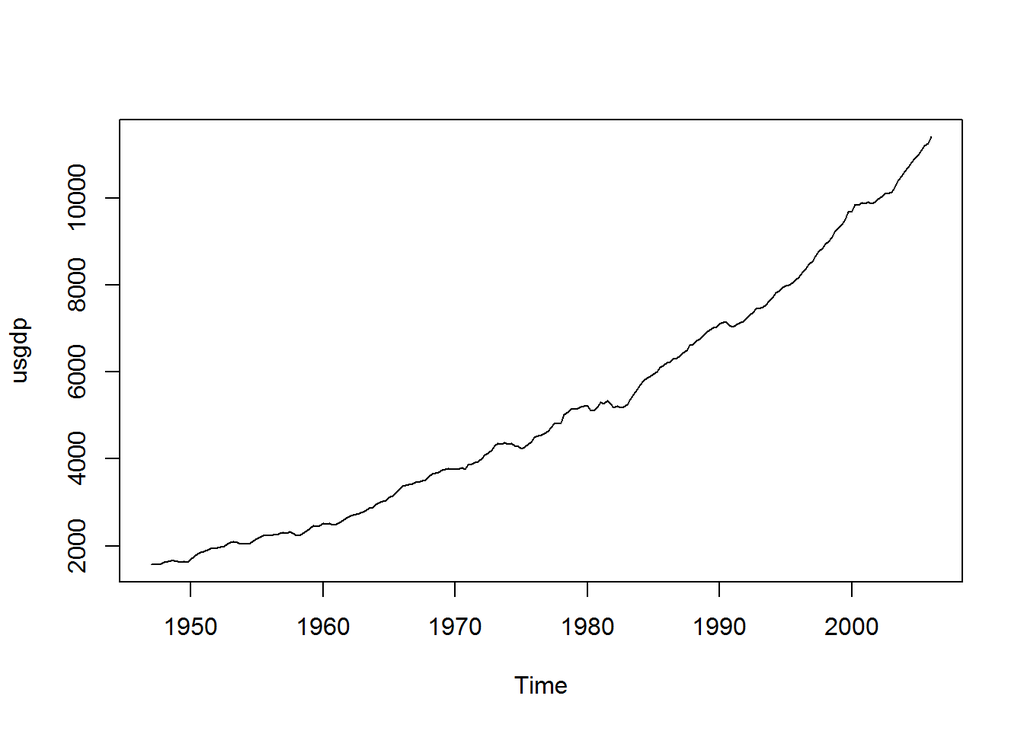

```r
plot(usgdp) # duomenys nestacionarūs, nes matomas trendas
```

```r
lambdab <- BoxCox.lambda(usgdp) # lambdos radimas
lambdab
```

```
## [1] 0.366352
```

```r
b <- BoxCox(usgdp, lambdab) # įvykdoma Box-Cox transformacija
nb <- ndiffs(usgdp) # surandama diferencijavimo eilė
nb
```

```
## [1] 2
```

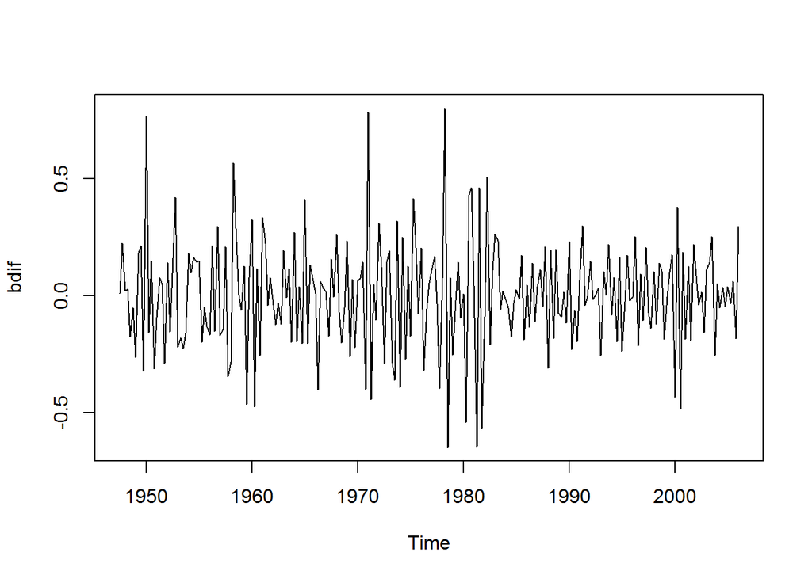

```r
bdif <- diff(b, differences=nb) # diferencijuojami duomenys
plot(bdif)
```

KPSS testas leis nustatyti, ar H0: duomenys stacionarūs.

```r
kpss.test(bdif)
```

```
##
##  KPSS Test for Level Stationarity
##
## data:  bdif
## KPSS Level = 0.0103, Truncation lag parameter = 3, p-value = 0.1
```

p-value = 0.1 > 0.05, vadinasi transformuoti duomenys yra stacionarūs.

- **(c) mcopper**

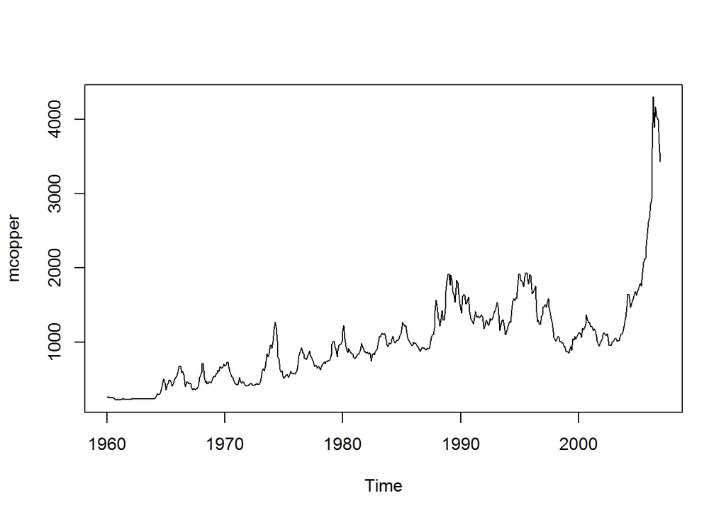

```r
plot(mcopper)
```

Grafikas jau kardinaliai skiriasi nuo a ir b atvejų. Galime pažiūrėti, ar duomenyse yra sezoniškumas.

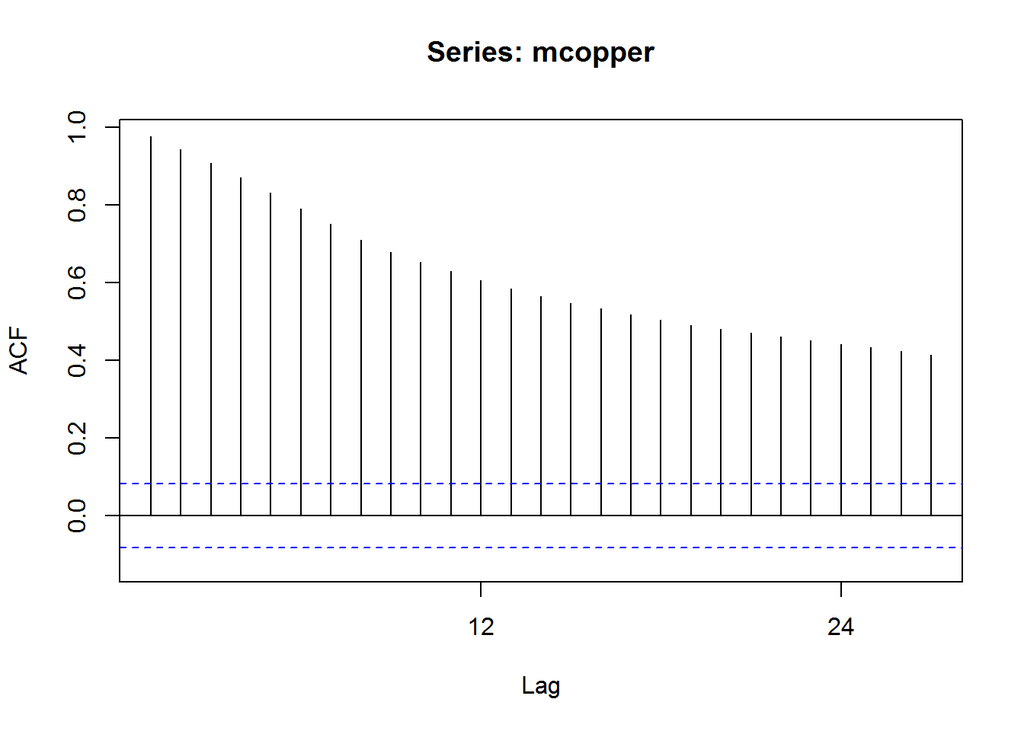

```r
Acf(mcopper) # sezoniškumo nesimato
```

```r
lambdac <- BoxCox.lambda(mcopper) # lambdos radimas
lambdac
```

```
## [1] 0.1919047
```

```r
c <- BoxCox(mcopper, lambdac) # įvykdoma Box-Cox transformacija
nc <- ndiffs(mcopper) # surandama diferencijavimo eilė
nc
```

```
## [1] 1
```

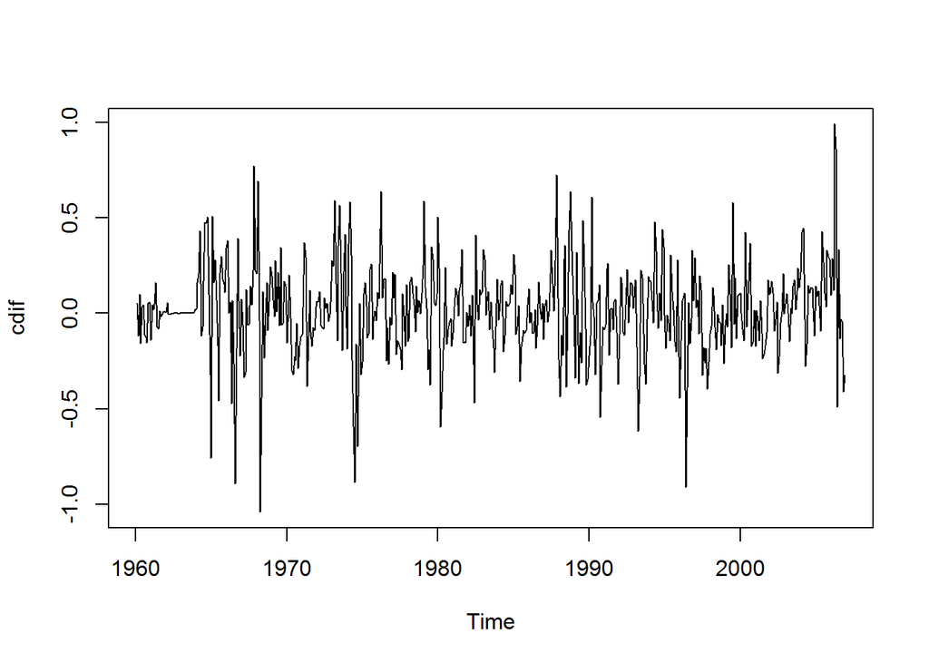

```r
cdif <- diff(c, differences=nc) # diferencijuojami duomenys
plot(cdif)
```

```r
kpss.test(cdif)
```

```
##
##  KPSS Test for Level Stationarity
##
## data:  cdif
## KPSS Level = 0.0584, Truncation lag parameter = 5, p-value = 0.1
```

p-value = 0.1 > 0.05, vadinasi transformuoti duomenys yra stacionarūs.

- **(d) enplanements**

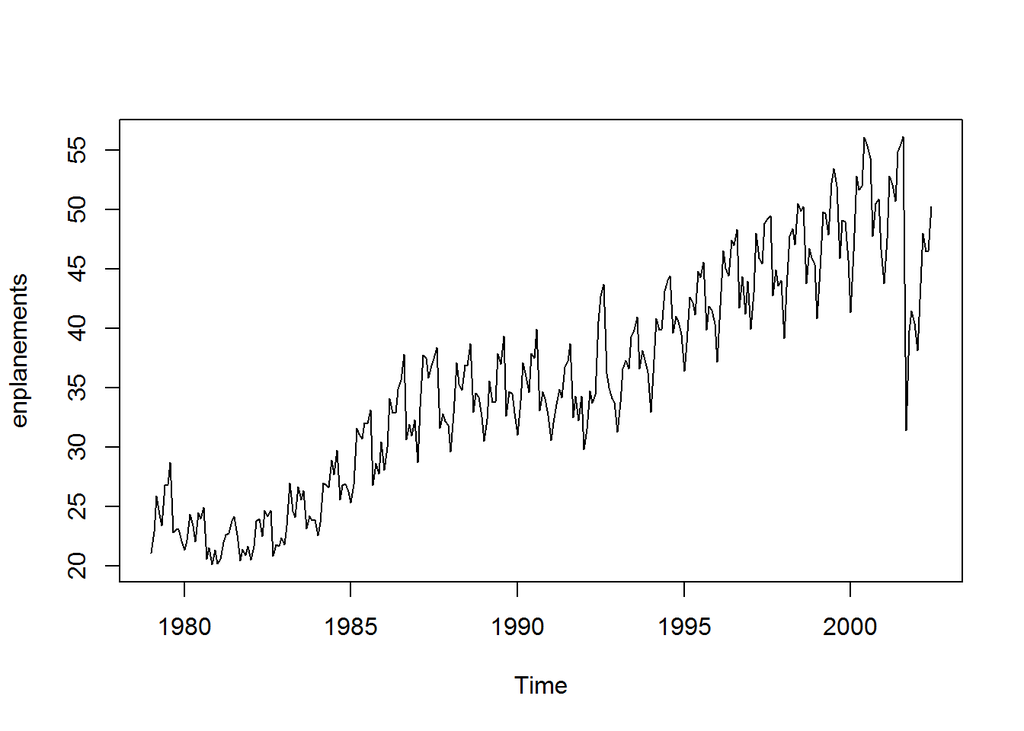

```r
plot(enplanements)
```

Šįkart panašu, kad duomenims įtaką daro sezoniškumas. Galime įsitikinti:

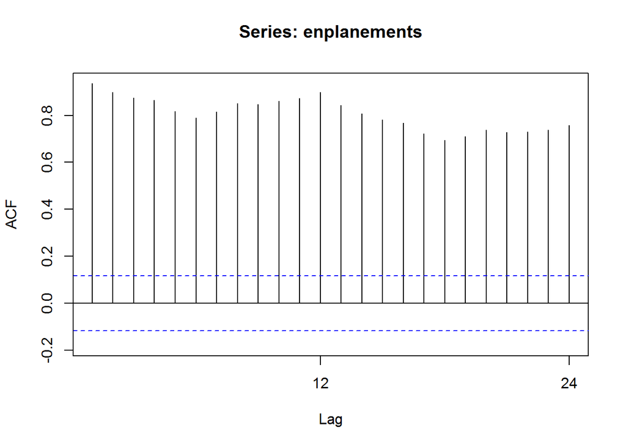

```r
Acf(enplanements) # duomenims tikrai įtaką daro sezoniškumas
```

Kadangi pastebimas sezoniškumas, reikės naudoti nebe ndiffs, bet nsdiffs funkciją.

```r
lambdad <- BoxCox.lambda(enplanements) # lambdos radimas
lambdad
```

```
## [1] -0.2269461
```

```r
d <- BoxCox(enplanements, lambdad) # įvykdoma Box-Cox transformacija
nd <- nsdiffs(enplanements) # surandama diferencijavimo eilė
nd
```

```
## [1] 1
```

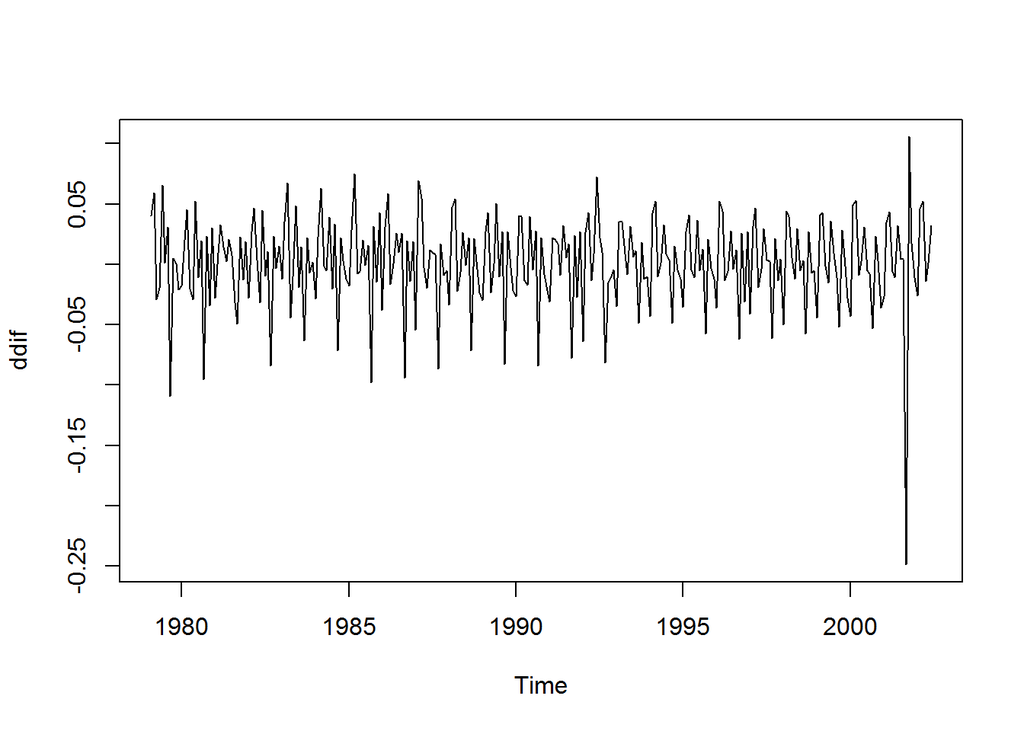

```r
ddif <- diff(d, differences=nd) # diferencijuojami duomenys
plot(ddif)
```

KPSS testas leis nustatyti, ar H0: duomenys stacionarūs.

```r
kpss.test(ddif)
```

```
##
##  KPSS Test for Level Stationarity
##
## data:  ddif
## KPSS Level = 0.0166, Truncation lag parameter = 3, p-value = 0.1
```

p-value = 0.1 > 0.05, vadinasi transformuoti duomenys yra stacionarūs.

- **(e) visitors**

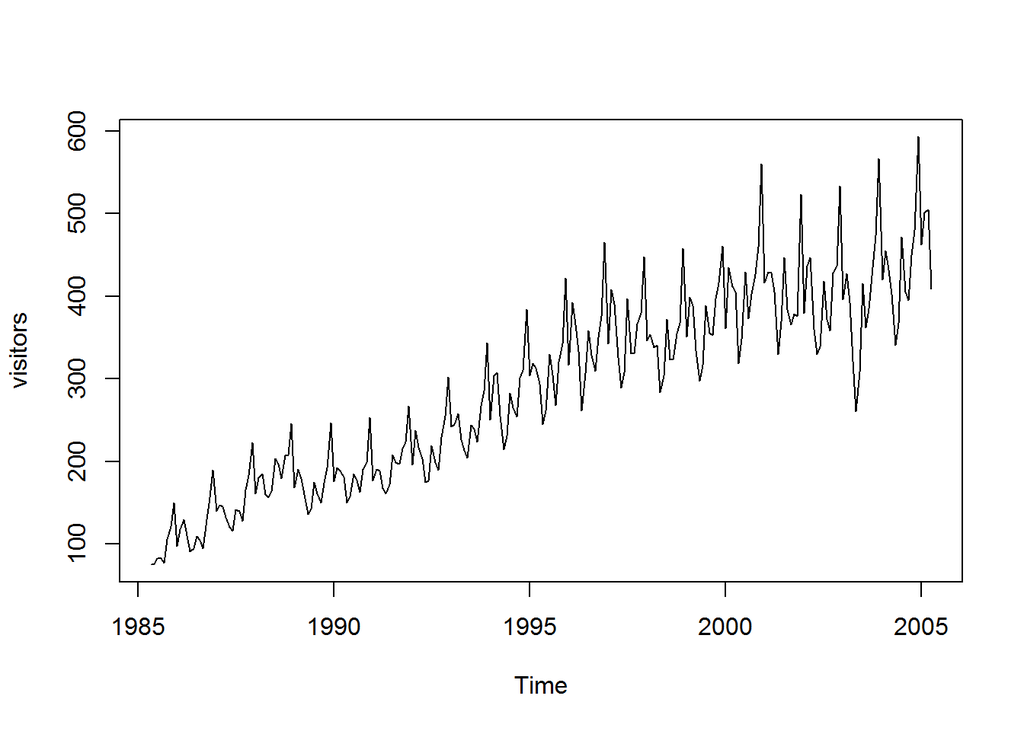

```r
plot(visitors)
```

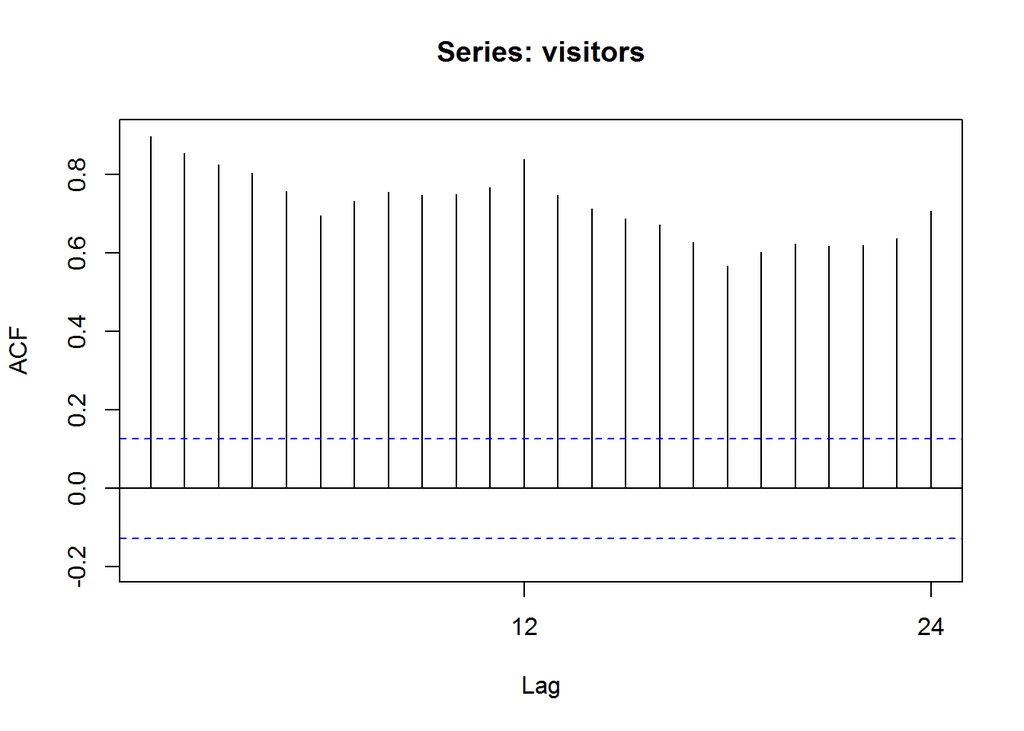

```r
Acf(visitors) # duomenims įtaką daro sezoniškumas
```

```r
lambdae <- BoxCox.lambda(visitors) # lambdos radimas
lambdae
```

```
## [1] 0.2775249
```

```r
e <- BoxCox(visitors, lambdae) # įvykdoma Box-Cox transformacija
ne <- nsdiffs(visitors) # surandama diferencijavimo eilė
ne
```

```
## [1] 1
```

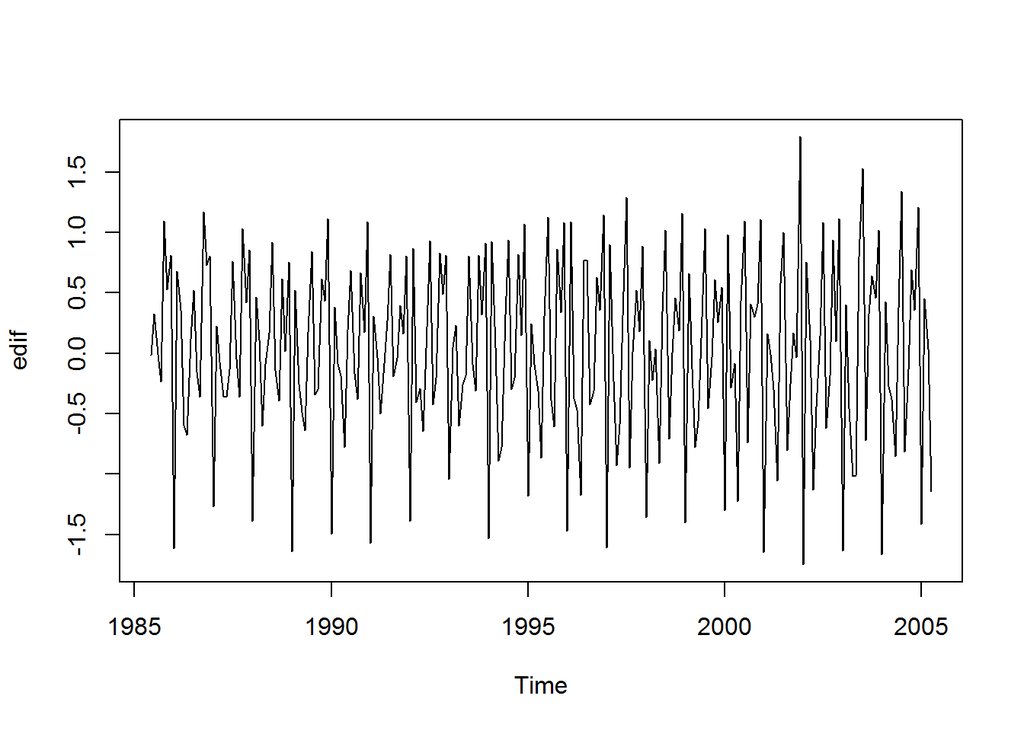

```r
edif <- diff(e, differences=ne) # diferencijuojami duomenys
plot(edif)
```

KPSS testas leis nustatyti, ar H0: duomenys stacionarūs.

```r
kpss.test(edif)
```

```
##
##  KPSS Test for Level Stationarity
##
## data:  edif
## KPSS Level = 0.0526, Truncation lag parameter = 3, p-value = 0.1
```

p-value = 0.1 > 0.05, vadinasi transformuoti duomenys yra stacionarūs.

## 2. Why is a Box-Cox transformation unhelpful for the cangas data?

```r
lambda_cangas <- BoxCox.lambda(cangas) # lambdos radimas
lambda_cangas
```

```
## [1] 0.5767759
```

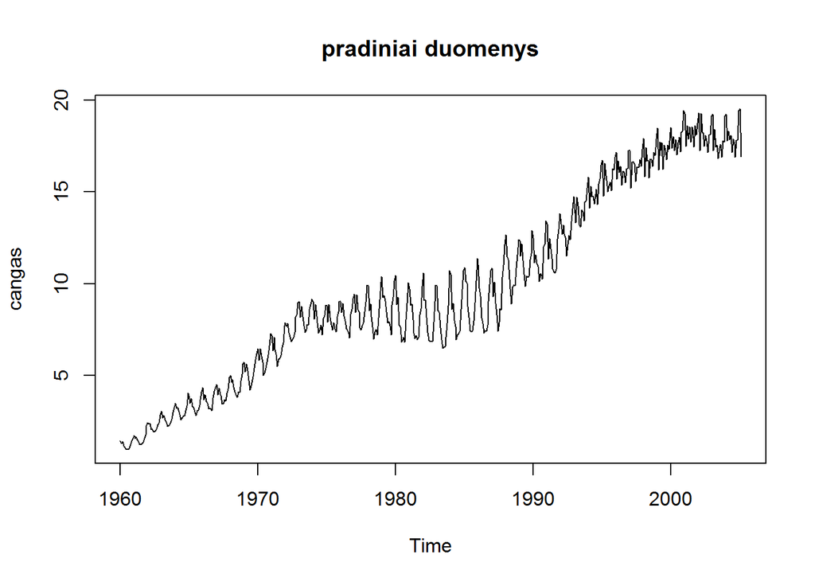

```r
cang <- BoxCox(cangas, lambda_cangas) # įvykdoma Box-Cox transformacija
plot(cangas, main="pradiniai duomenys")
```

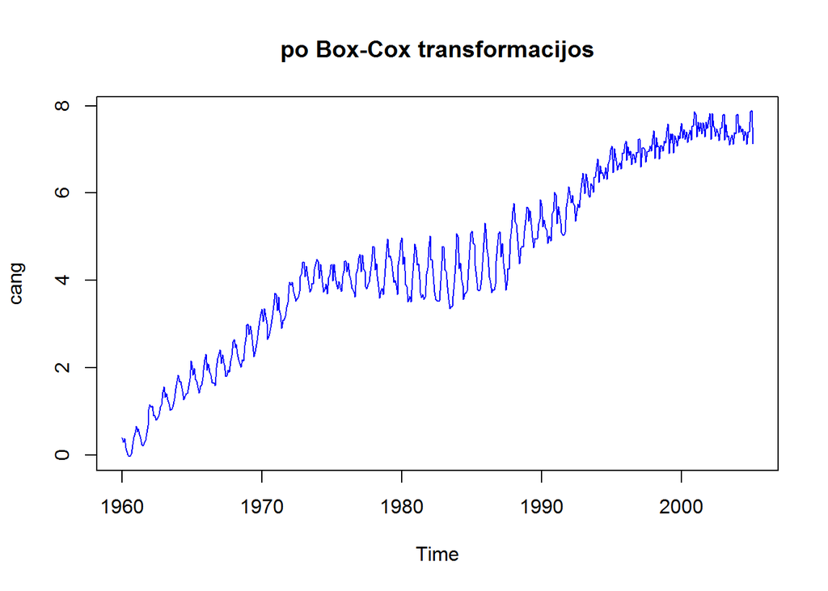

```r
plot(cang, main="po Box-Cox transformacijos", col="blue")
```

Box-Cox transformacija šiuo atveju nėra naudinga, kadangi labai skiriasi pradinių/galinių bei vidurinių duomenų sklaidos, todėl transformacija negali prisitaikyti visiems duomenims.

## 3. Download the data at http://robjhyndman.com/data/retail.xls. Choose one of the series and find an appropriate Box-Cox transformation and order of differencing in order to obtain stationary data.

Nuskaitome duomenis.

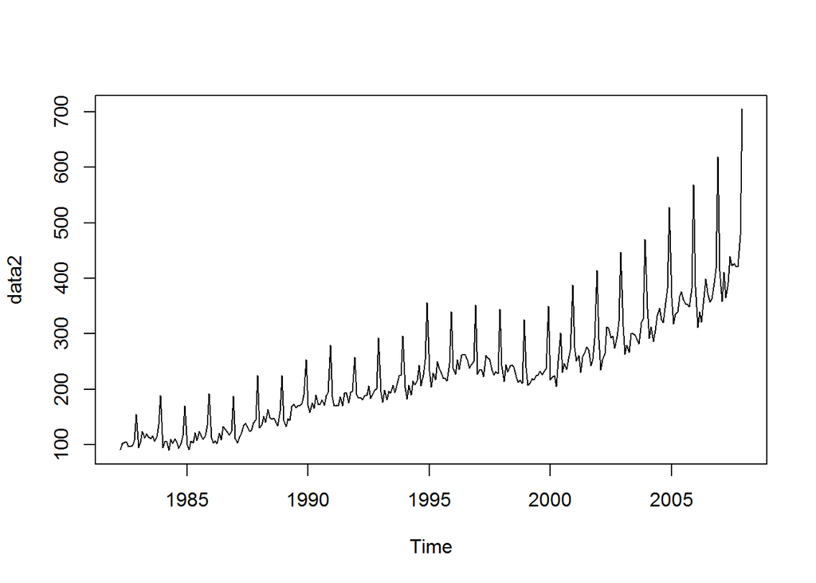

```r
data = read.csv2("retail.csv", header = TRUE)
data1 <- data[,7] # naudosimės septintu duomenų stulpeliu
data2 <- ts(data1, start=c(1982,4), frequency=12) # sukuriama laiko eilutė
plot(data2)
```

```r
kpss.test(data2) # pastebima, kad pradiniuose duomenyse stacionarumo nėra
```

```
##
##  KPSS Test for Level Stationarity
##
## data:  data2
## KPSS Level = 5.6723, Truncation lag parameter = 4, p-value = 0.01
```

```r
lambda <- BoxCox.lambda(data2) # lambdos radimas
lambda
```

```
## [1] 0.05749076
```

```r
transformacija <- BoxCox(data2, lambda)
n <- nsdiffs(data2) # nsdiffs - nes duomenys sezoniški (surandama diferencijavimo eilė)
n
```

```
## [1] 1
```

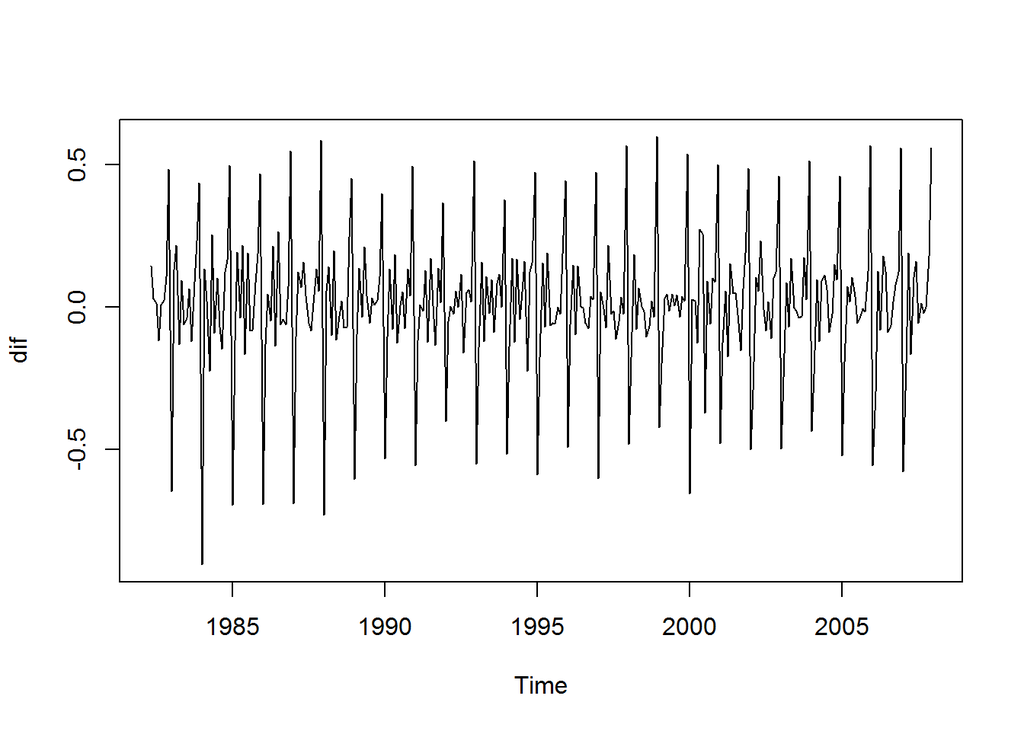

```r
dif <- diff(transformacija, differences=n) # diferencijuojami duomenys
plot(dif)
```

```r
kpss.test(dif)
```

```
##
##  KPSS Test for Level Stationarity
##
## data:  dif
## KPSS Level = 0.048, Truncation lag parameter = 4, p-value = 0.1
```

Pritaikius Box-Cox transformavimą ir diferencijavimą, duomenyse atsirado stacionarumas, nes p-value = 0.1 > 0.05